# ST 533 Midterm 1

Tyler Schappe

9/19/2020

```r
citation("reshape2")
```

```
  Hadley Wickham (2007). Reshaping Data with the reshape Package. Journal of Statistical Software, 21(12), 1-20. URL http://www.jstatsoft.org/v21/i12/.

A BibTeX entry for LaTeX users is

  @Article{,
    title = {Reshaping Data with the {reshape} Package},
    author = {Hadley Wickham},
    journal = {Journal of Statistical Software},
    year = {2007},
    volume = {21},
    number = {12},
    pages = {1--20},
    url = {http://www.jstatsoft.org/v21/i12/},
  }
```

### Get the data in order

Load the raw data

```r
fl.20 <- read.csv("/Volumes/\ macOS\ -\ Data/Users/tyler/Documents/Fall\ 2020/ST533/midterm1/data/fl_20.csv")
ga.20 <- read.csv("/Volumes/\ macOS\ -\ Data/Users/tyler/Documents/Fall\ 2020/ST533/midterm1/data/ga_20.csv")
nc.20 <- read.csv("/Volumes/\ macOS\ -\ Data/Users/tyler/Documents/Fall\ 2020/ST533/midterm1/data/nc_20.csv")
sc.20 <- read.csv("/Volumes/\ macOS\ -\ Data/Users/tyler/Documents/Fall\ 2020/ST533/midterm1/data/sc_20.csv")
va.20 <- read.csv("/Volumes/\ macOS\ -\ Data/Users/tyler/Documents/Fall\ 2020/ST533/midterm1/data/va_20.csv")
fl.19 <- read.csv("/Volumes/\ macOS\ -\ Data/Users/tyler/Documents/Fall\ 2020/ST533/midterm1/data/fl_19.csv")
ga.19 <- read.csv("/Volumes/\ macOS\ -\ Data/Users/tyler/Documents/Fall\ 2020/ST533/midterm1/data/ga_19.csv")
nc.19 <- read.csv("/Volumes/\ macOS\ -\ Data/Users/tyler/Documents/Fall\ 2020/ST533/midterm1/data/nc_19.csv")
sc.19 <- read.csv("/Volumes/\ macOS\ -\ Data/Users/tyler/Documents/Fall\ 2020/ST533/midterm1/data/sc_19.csv")
va.19 <- read.csv("/Volumes/\ macOS\ -\ Data/Users/tyler/Documents/Fall\ 2020/ST533/midterm1/data/va_19.csv")
```

Add an identifier column to each one and then combine them and extract just April-June

```r
#Add a year column by stripping the date column
fl.20$year <- gsub('[0-9]+\\/[0-9]+\\/', '', fl.20$Date)
fl.19$year <- gsub('[0-9]+\\/[0-9]+\\/', '', fl.19$Date)
ga.20$year <- gsub('[0-9]+\\/[0-9]+\\/', '', ga.20$Date)
ga.19$year <- gsub('[0-9]+\\/[0-9]+\\/', '', ga.19$Date)
nc.20$year <- gsub('[0-9]+\\/[0-9]+\\/', '', nc.20$Date)
nc.19$year <- gsub('[0-9]+\\/[0-9]+\\/', '', nc.19$Date)
sc.20$year <- gsub('[0-9]+\\/[0-9]+\\/', '', sc.20$Date)
sc.19$year <- gsub('[0-9]+\\/[0-9]+\\/', '', sc.19$Date)
va.20$year <- gsub('[0-9]+\\/[0-9]+\\/', '', va.20$Date)
va.19$year <- gsub('[0-9]+\\/[0-9]+\\/', '', va.19$Date)
#Convert the date text column to a recognized date format
fl.20$Date2 <- as.Date(fl.20$Date, format = "%m/%d/%y%y")
fl.19$Date2 <- as.Date(fl.19$Date, format = "%m/%d/%y%y")
ga.20$Date2 <- as.Date(ga.20$Date, format = "%m/%d/%y%y")
ga.19$Date2 <- as.Date(ga.19$Date, format = "%m/%d/%y%y")
nc.20$Date2 <- as.Date(nc.20$Date, format = "%m/%d/%y%y")
nc.19$Date2 <- as.Date(nc.19$Date, format = "%m/%d/%y%y")
sc.20$Date2 <- as.Date(sc.20$Date, format = "%m/%d/%y%y")
sc.19$Date2 <- as.Date(sc.19$Date, format = "%m/%d/%y%y")
va.20$Date2 <- as.Date(va.20$Date, format = "%m/%d/%y%y")
va.19$Date2 <- as.Date(va.19$Date, format = "%m/%d/%y%y")
#Combine them together
dat.20 <- rbind(
  fl.20, ga.20, nc.20, sc.20, va.20
)
dat.19 <- rbind(
  fl.19, ga.19, nc.19, sc.19, va.19
)
#Extract just April - June
dat.20.aj <- dat.20[dat.20$Date2 >= "2020-04-01" & dat.20$Date2 <= "2020-06-30",]
dat.19.aj <- dat.19[dat.19$Date2 >= "2019-04-01" & dat.19$Date2 <= "2019-06-30",]

#Keep only sites that are present in both datasets
sites.20 <- unique(dat.20.aj$Site.ID)
sites.19 <- unique(dat.19.aj$Site.ID)
dat.20.aj.site <- dat.20.aj[dat.20.aj$Site.ID %in% sites.19, ]
dat.19.aj.site <- dat.19.aj[dat.19.aj$Site.ID %in% sites.20, ]
#Check if the sites are the same
identical(sort(unique(dat.20.aj.site$Site.ID)), sort(unique(dat.19.aj.site$Site.ID)))
```

```
[1] TRUE
```

```r
#They are, but the # of obs is different - there must be some sites that have more measurements in one year than another, but that's fine because we're going to average

#Look at a summary for 2.5 concentration
summary(dat.20.aj.site$Daily.Mean.PM2.5.Concentration)
```

```
   Min. 1st Qu.  Median    Mean 3rd Qu.    Max.
  -4.50    5.10    6.80    7.59    8.90   73.90
```

```r
summary(dat.19.aj.site$Daily.Mean.PM2.5.Concentration)
```

```
   Min. 1st Qu.  Median    Mean 3rd Qu.    Max.
  -3.10    5.60    7.40    8.22   10.20   40.40
```

```r
#Remove negative values
dat.20.aj.site <- dat.20.aj.site[dat.20.aj.site$Daily.Mean.PM2.5.Concentration >= 0, ]
dat.19.aj.site <- dat.19.aj.site[dat.19.aj.site$Daily.Mean.PM2.5.Concentration >= 0, ]

#Make sure each site has at least 10 measurements
length(dat.20.aj.site$Daily.Mean.PM2.5.Concentration[is.na(dat.20.aj.site$Daily.Mean.PM2.5.Concentration)])
```

```
[1] 0
```

```r
tapply(dat.20.aj.site$Daily.Mean.PM2.5.Concentration, dat.20.aj.site$Site.ID, length)[tapply(dat.20.aj.site$Daily.Mean.PM2.5.Concentration, dat.20.aj.site$Site.ID, length) < 10]
```

```
named integer(0)
```

```r
tapply(dat.19.aj.site$Daily.Mean.PM2.5.Concentration, dat.19.aj.site$Site.ID, length)[tapply(dat.19.aj.site$Daily.Mean.PM2.5.Concentration, dat.19.aj.site$Site.ID, length) < 10]
```

```
named integer(0)
```

Grab the first row for each site in each dataset and create new dataframes to hold the mean data

```r
by.site.20 <- as.data.frame(matrix(nrow = length(unique(dat.20.aj.site$Site.ID)), ncol=ncol(dat.20.aj.site), data=NA))
for (i in 1:length(unique(dat.20.aj.site$Site.ID))) {
  by.site.20[i,] <- dat.20.aj.site[dat.20.aj.site$Site.ID == unique(dat.20.aj.site$Site.ID)[i], ][1,]
}
colnames(by.site.20) <- colnames(dat.20.aj.site)

by.site.19 <- as.data.frame(matrix(nrow = length(unique(dat.19.aj.site$Site.ID)), ncol=ncol(dat.19.aj.site), data=NA))
for (i in 1:length(unique(dat.19.aj.site$Site.ID))) {
  by.site.19[i,] <- dat.19.aj.site[dat.19.aj.site$Site.ID == unique(dat.19.aj.site$Site.ID)[i], ][1,]
}
colnames(by.site.19) <- colnames(dat.19.aj.site)

#Remove old PM2.5 measurement column
by.site.20 <- subset(by.site.20, select = -c(Daily.Mean.PM2.5.Concentration))
by.site.19 <- subset(by.site.19, select = -c(Daily.Mean.PM2.5.Concentration))
```

Loop over each station and calculate the mean across all dates for that station for each year

```r
by.site.20$pm <- sapply(unique(dat.20.aj.site$Site.ID), FUN = function(x) mean(dat.20.aj.site$Daily.Mean.PM2.5.Concentration[dat.20.aj.site$Site.ID == x]))
by.site.19$pm <- sapply(unique(dat.19.aj.site$Site.ID), FUN = function(x) mean(dat.19.aj.site$Daily.Mean.PM2.5.Concentration[dat.19.aj.site$Site.ID == x]))
```

Loop over the stations and calculate the difference in means

```r
by.site.final <- by.site.20
by.site.final$pm.diff <- sapply(unique(by.site.20$Site.ID), FUN = function(x) by.site.20$pm[by.site.20$Site.ID == x] - by.site.19$pm[by.site.19$Site.ID == x])
by.site.final <- subset(by.site.final, select = -c(pm))
```

Add a state column

```r
by.site.final$State <- NA
by.site.final$State[by.site.final$STATE == "Florida"] <- "FL"
by.site.final$State[by.site.final$STATE == "Georgia"] <- "GA"
by.site.final$State[by.site.final$STATE == "North Carolina"] <- "NC"
by.site.final$State[by.site.final$STATE == "South Carolina"] <- "SC"
by.site.final$State[by.site.final$STATE == "Virginia"] <- "VA"
```

### Covariates

#### Population Density

Read in the 30 arc-second (0.0083 degrees) data

```r
fl.area <- read.table("/Users/tschappe/Downloads/usgrid_data_2010/dat/flarea10.asc")
fl.house <- read.table("/Users/tschappe/Downloads/usgrid_data_2010/dat/flhh10.asc")
fl.pop <- read.table("/Users/tschappe/Downloads/usgrid_data_2010/dat/flpop10.asc")
ga.area <- read.table("/Users/tschappe/Downloads/usgrid_data_2010/dat/gaarea10.asc")
ga.house <- read.table("/Users/tschappe/Downloads/usgrid_data_2010/dat/gahh10.asc")
ga.pop <- read.table("/Users/tschappe/Downloads/usgrid_data_2010/dat/gapop10.asc")
nc.area <- read.table("/Users/tschappe/Downloads/usgrid_data_2010/dat/ncarea10.asc")
nc.house <- read.table("/Users/tschappe/Downloads/usgrid_data_2010/dat/nchh10.asc")
nc.pop <- read.table("/Users/tschappe/Downloads/usgrid_data_2010/dat/ncpop10.asc")
sc.area <- read.table("/Users/tschappe/Downloads/usgrid_data_2010/dat/scarea10.asc")
sc.house <- read.table("/Users/tschappe/Downloads/usgrid_data_2010/dat/schh10.asc")
sc.pop <- read.table("/Users/tschappe/Downloads/usgrid_data_2010/dat/scpop10.asc")
va.area <- read.table("/Users/tschappe/Downloads/usgrid_data_2010/dat/vaarea10.asc")
va.house <- read.table("/Users/tschappe/Downloads/usgrid_data_2010/dat/vahh10.asc")
va.pop <- read.table("/Users/tschappe/Downloads/usgrid_data_2010/dat/vapop10.asc")
```

Replace missing value -99999 with 0. This is justified because some of the sensors on the coast will have the density overesimated because the NAs from the ocean don’t count.

```r
fl.pop <- as.data.frame(t(apply(fl.pop, 1, FUN = function(x) as.vector(sapply(x, FUN = function(y) as.numeric(gsub('-9999', '0', y)))))))
ga.pop <- as.data.frame(t(apply(ga.pop, 1, FUN = function(x) as.vector(sapply(x, FUN = function(y) as.numeric(gsub('-9999', '0', y)))))))
nc.pop <- as.data.frame(t(apply(nc.pop, 1, FUN = function(x) as.vector(sapply(x, FUN = function(y) as.numeric(gsub('-9999', '0', y)))))))
sc.pop <- as.data.frame(t(apply(sc.pop, 1, FUN = function(x) as.vector(sapply(x, FUN = function(y) as.numeric(gsub('-9999', '0', y)))))))
va.pop <- as.data.frame(t(apply(va.pop, 1, FUN = function(x) as.vector(sapply(x, FUN = function(y) as.numeric(gsub('-9999', '0', y)))))))

# for (i in 1:nrow(fl.area)) {
#   fl.area[i, ][fl.area[i, ] == -9999] <- 0
# }
# for (i in 1:nrow(fl.house)) {
#   fl.house[i, ][fl.house[i, ] == -9999] <- 0
# }
# for (i in 1:nrow(fl.pop)) {
#   fl.pop[i, ][fl.pop[i, ] == -9999] <- 0
# }
# for (i in 1:nrow(ga.area)) {
#   ga.area[i, ][ga.area[i, ] == -9999] <- 0
# }
# for (i in 1:nrow(ga.house)) {
#   ga.house[i, ][ga.house[i, ] == -9999] <- 0
# }
# for (i in 1:nrow(ga.pop)) {
#   ga.pop[i, ][ga.pop[i, ] == -9999] <- 0
# }
# for (i in 1:nrow(nc.area)) {
#   nc.area[i, ][nc.area[i, ] == -9999] <- 0
# }
# for (i in 1:nrow(nc.house)) {
#   nc.house[i, ][nc.house[i, ] == -9999] <- 0
# }
# for (i in 1:nrow(nc.pop)) {
#   nc.pop[i, ][nc.pop[i, ] == -9999] <- 0
# }
# for (i in 1:nrow(sc.area)) {
#   sc.area[i, ][sc.area[i, ] == -9999] <- 0
# }
# for (i in 1:nrow(sc.house)) {
#   sc.house[i, ][sc.house[i, ] == -9999] <- 0
# }
# for (i in 1:nrow(sc.pop)) {
#   sc.pop[i, ][sc.pop[i, ] == -9999] <- 0
# }
# for (i in 1:nrow(va.area)) {
#   va.area[i, ][va.area[i, ] == -9999] <- 0
# }
# for (i in 1:nrow(va.house)) {
#   va.house[i, ][va.house[i, ] == -9999] <- 0
# }
# for (i in 1:nrow(va.pop)) {
#   va.pop[i, ][va.pop[i, ] == -9999] <- 0
# }
#
# #Replace missing value -99999 with NA
# for (i in 1:nrow(fl.area)) {
#   fl.area[i, ][fl.area[i, ] == -9999] <- NA
# }
# for (i in 1:nrow(fl.house)) {
#   fl.house[i, ][fl.house[i, ] == -9999] <- NA
# }
# for (i in 1:nrow(fl.pop)) {
#   fl.pop[i, ][fl.pop[i, ] == -9999] <- NA
# }
# for (i in 1:nrow(ga.area)) {
#   ga.area[i, ][ga.area[i, ] == -9999] <- NA
# }
# for (i in 1:nrow(ga.house)) {
#   ga.house[i, ][ga.house[i, ] == -9999] <- NA
# }
# for (i in 1:nrow(ga.pop)) {
#   ga.pop[i, ][ga.pop[i, ] == -9999] <- NA
# }
# for (i in 1:nrow(nc.area)) {
#   nc.area[i, ][nc.area[i, ] == -9999] <- NA
# }
# for (i in 1:nrow(nc.house)) {
#   nc.house[i, ][nc.house[i, ] == -9999] <- NA
# }
# for (i in 1:nrow(nc.pop)) {
#   nc.pop[i, ][nc.pop[i, ] == -9999] <- NA
# }
# for (i in 1:nrow(sc.area)) {
#   sc.area[i, ][sc.area[i, ] == -9999] <- NA
# }
# for (i in 1:nrow(sc.house)) {
#   sc.house[i, ][sc.house[i, ] == -9999] <- NA
# }
# for (i in 1:nrow(sc.pop)) {
#   sc.pop[i, ][sc.pop[i, ] == -9999] <- NA
# }
# for (i in 1:nrow(va.area)) {
#   va.area[i, ][va.area[i, ] == -9999] <- NA
# }
# for (i in 1:nrow(va.house)) {
#   va.house[i, ][va.house[i, ] == -9999] <- NA
# }
# for (i in 1:nrow(va.pop)) {
#   va.pop[i, ][va.pop[i, ] == -9999] <- NA
# }

# nc.pop.mat <- ((as.matrix(nc.pop)))
# sort(apply(nc.pop, 1, FUN = function(x) max(na.omit(x))))
#
# fl.pop.mat <- ((as.matrix(fl.pop)))
# sort(apply(fl.pop, 1, FUN = function(x) max(na.omit(x))))
# sort(fl.pop.mat, decreasing = T)
```

By state, find the grid location for each monitoring site and grab its population density

```r
grid.inc <- 0.0083333333333333
fl.start <- c(-87.641666666542, 24.516666666636)
ga.start <- c(-85.608333333764, 30.350000000375)
nc.start <- c(-84.324999999782, 33.833333333756)
sc.start <- c(-83.358333333379, 32.033333333248)
va.start <- c(-83.683333333791, 36.533333333018)
states <- c("FL", "GA", "NC", "SC", "VA")
starts <- as.matrix(cbind(rbind(fl.start, ga.start, nc.start, sc.start, va.start), as.integer(c(nrow(fl.pop), nrow(ga.pop), nrow(nc.pop), nrow(sc.pop), nrow(va.pop)))))
starts.df <- as.data.frame(cbind(starts, states))
colnames(starts.df) <- c("lon", "lat", "nrow", "state")
#Add a state column to

#Loop over states and grab the proper indices within each state's grid for the target cell (the one where the station is located). Note that the coordinates of the cells are the lower left corner, so we use floor to round down to them.
#What we do is for both longitide and latitude, we find the difference in degrees between the baseline cell of that state's grid (lower left) and the coordinates of the measurement station, then divide that difference by the size of each cell, to get number of cells from the grid baseline. We round down since the grid cells are referenced by lower lefthand corner. Do this for each state and combine them into a list of "target" grids for each state.
cells <- list(NULL)
for (i in 1:length(states)) {
  cells[[i]] <- cbind(floor((by.site.final$SITE_LONGITUDE[by.site.final$State == states[i]] - starts[i,1])/grid.inc), floor((by.site.final$SITE_LATITUDE[by.site.final$State == states[i]] - starts[i,2])/grid.inc))
}
#Turn this into a dataframe
cells.df <- as.data.frame(do.call('rbind', cells))
#Add a state column
cells.df$state <- by.site.final$State
#Make list of the raw grid data for the states
grids <- list(
  fl.pop, ga.pop, nc.pop, sc.pop, va.pop
)
#Give the grid list items the names of the states so we can grab them by name
names(grids) <- states

#Loop over the desired grid cells, find all cells within 10 cells of the target cell (a square with sides of 630 arc seconds, or 0.175 arc degree, or about 10.5 miles centered on the target grid; or roughly a circle with radius 5.5 miles around the station)
cell.feather <- 100
for (i in 1:nrow(cells.df)) { #Loop over the rows of the cell indices desired
  by.site.final$pop.dens[i] <-
    mean(
      as.matrix(
        #Subset the grid list to get the proper state's grid
        grids[[names(grids)[names(grids) == cells.df$state[i]]]]
          #Subset the rows of the grid based on the cell number found in the cells.df column, and keep in mind that we have to work backwards for the rows because the cells start in the bottom left for the grid, so subract the desired cell row from the number of total cells.
          #When you jitter by 10 cells, account for the fact that we may be less than 10 cells away from the edge of the grid, so take the min of 10 or the difference between the current row and the total number of rows. This is the lower bound for the rows, so subtract 10 (or min)
          [(as.integer(starts.df$nrow[starts.df$state == cells.df$state[i]]) - cells.df$V2[i] - min(cell.feather, as.integer(starts.df$nrow[starts.df$state == cells.df$state[i]]) - cells.df$V2[i]))
            #This is the upper bound for the rows, so add 10 (or min)
            :(as.integer(starts.df$nrow[starts.df$state == cells.df$state[i]]) - cells.df$V2[i] + min(cell.feather, as.integer(starts.df$nrow[starts.df$state == cells.df$state[i]]) - cells.df$V2[i])),
            #The columns are easier because the indices are in the same order as the grid, so we just need to subtract the lower and upper bound as 10 or min.
            (cells.df$V1[i] - min(cell.feather, cells.df$V1[i], ncol(grids[[names(grids)[names(grids) == cells.df$state[i]]]]) - cells.df$V1[i]))
            :(cells.df$V1[i] + min(cell.feather, cells.df$V1[i], ncol(grids[[names(grids)[names(grids) == cells.df$state[i]]]]) - cells.df$V1[i]))]
      ), #Return a matrix
    na.rm = T) #Find the mean of all of the cells, excluding NAs
}



###############3
#Below was the test code to get the above loop to work on the first observation in the by.sites.final dataset from FL
##############3
#
# cells.test <- list(NULL)
# for (i in 1:nrow(cells.df)) { #Loop over the rows of the cell indices desired
#   cells.test[[i]] <-
#       as.matrix(
#         #Subset the grid list to get the proper state's grid
#         grids[[names(grids)[names(grids) == cells.df$state[i]]]]
#           #Subset the rows of the grid based on the cell number found in the cells.df column, and keep in mind that we have to work backwards for the rows because the cells start in the bottom left for the grid, so subract the desired cell row from the number of total cells.
#           #When you jitter by 10 cells, account for the fact that we may be less than 10 cells away from the edge of the grid, so take the min of 10 or the difference between the current row and the total number of rows. This is the lower bound for the rows, so subtract 10 (or min)
#           [(as.integer(starts.df$nrow[starts.df$state == cells.df$state[i]]) - cells.df$V2[i] - min(cell.feather, as.integer(starts.df$nrow[starts.df$state == cells.df$state[i]]) - cells.df$V2[i]))
#             #This is the upper bound for the rows, so add 10 (or min)
#             :(as.integer(starts.df$nrow[starts.df$state == cells.df$state[i]]) - cells.df$V2[i] + min(cell.feather, as.integer(starts.df$nrow[starts.df$state == cells.df$state[i]]) - cells.df$V2[i])),
#             (cells.df$V1[i] - min(cell.feather, cells.df$V1[i], ncol(grids[[names(grids)[names(grids) == cells.df$state[i]]]]) - cells.df$V1[i]))
#             :(cells.df$V1[i] + min(cell.feather, cells.df$V1[i], ncol(grids[[names(grids)[names(grids) == cells.df$state[i]]]]) - cells.df$V1[i]))] #The columns are easier because the indices are in the same order as the grid, so we just need to subtract the lower and upper bound as 10 or min.
#       ) #Return a matrix
# }
#
# ct1 <- cells.test[[2]]
#
# apply(cells.df, 1, mean(fl.pop.mat[(779 - 605 - 10):(779 - 605 + 10), (-10 + 645):(10 + 645)], na.rm = T))
#
# c(fl.start[1] + grid.inc*646, fl.start[2] + grid.inc*606)
# fl.area[(-20 + 645):(20 + 645), (779 - 20 + 605):(779 + 20 + 605)]
# mean(fl.pop.mat[(779 - 605 - 10):(779 - 605 + 10), (-10 + 645):(10 + 645)], na.rm = T)
#
# fl.start[2] + 779*grid.inc
# fl.start[1] + 914*grid.inc
```

#### Socioeconomic vulnerability index

```r
svi <- read.csv("/Users/tschappe/Documents/NC\ State\ Classes/ST540/Final\ Project/SVI2018_US_COUNTY.csv")
#Remove 'City' from county column
svi$county <- gsub('\\sCity', '', svi$COUNTY)
#Make state_county column
svi$state_county <- paste(svi$ST_ABBR, svi$county, sep="_")
```

#### 2016 presidential election votes

```r
pres <- read.csv("/Users/tschappe/Documents/NC\ State\ Classes/ST540/Final\ Project/election-context-2018.csv")
# pres <- read.csv("/Volumes/tschappe/Documents/NC\ State\ Classes/ST540/Final\ Project/election-context-2018.csv")
#Calculate total votes for 2016 presidential election
pres$votes <- pres$trump16 + pres$clinton16 + pres$otherpres16
#Calculate percentage votes for Trump
pres$trump.per <- pres$trump16/pres$votes
#Get state abbreviations in from a key file
state.abb <- read.csv("/Users/tschappe/Documents/NC\ State\ Classes/ST540/Final\ Project/state_abb_key.csv")
# state.abb <- read.csv("/Volumes/tschappe/Documents/NC\ State\ Classes/ST540/Final\ Project/state_abb_key.csv")
#Make a new column with state abbreviations
state.abb$State <- as.character(state.abb$State)
state.abb$State <- gsub('^\\s', '', state.abb$State)
state.abb$Abb <- as.character(state.abb$Abb)
#Loop through and grab the abbreviation for each state
pres$state_abb <- 1:nrow(pres)
for (i in 1:nrow(pres)) {
  pres$state_abb[i] <- (state.abb$Abb[state.abb$State == pres$state[i]])
}
#Make state_county column
pres$state_county <- paste(pres$state_abb, pres$county, sep="_")
```

### Gather data together

Make a State_County column for the pollution data

```r
by.site.final$state_county <- paste0(by.site.final$State, "_", by.site.final$COUNTY)
#Remove any " City" from state_county
by.site.final$state_county <- gsub(' City', '', by.site.final$state_county)
```

Get SVI for each site

```r
#Remove troublesome counties in VA with " City" versions
svi2 <- svi
svi2 <- svi2[!(rownames(svi2) %in% c("2069", "2694", "2444")),]

# svi[svi$state_county == by.site.final$state_county[i],]

for (i in 1:nrow(by.site.final)) {
  by.site.final$svi[i] <- svi2$SPL_THEME1[svi2$state_county == by.site.final$state_county[i]]
}
```

Get 2016 pres election for each site

```r
#Remove troublesome counties in VA with " City" versions
pres2 <- pres
pres2 <- pres2[!(rownames(pres2) %in% c("2897", "2868", "2867")),]

# pres[grep("Charles", pres$county),]
# pres$county
# pres[pres$state_county == by.site.final$state_county[i],]

#Charles City county in VA
pres2$state_county[pres2$state_county == "VA_Charles City"] <- "VA_Charles"

by.site.final$trump.per <- NULL
for (i in 1:nrow(by.site.final)) {
  by.site.final$trump.per[i] <- pres2$trump.per[pres2$state_county == by.site.final$state_county[i]]
}
```

### Plot Response and Predictor

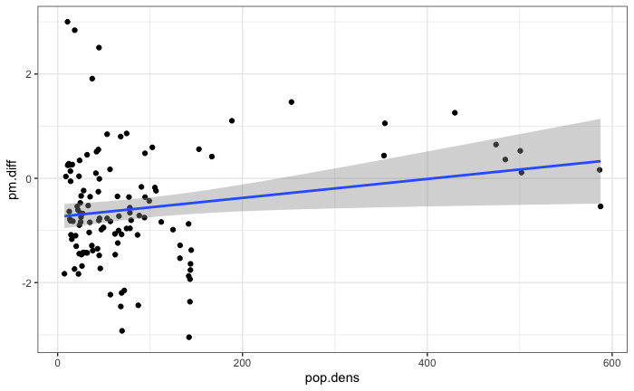

```r
qplot(pop.dens, pm.diff, data=by.site.final)+geom_smooth(method="lm")
```

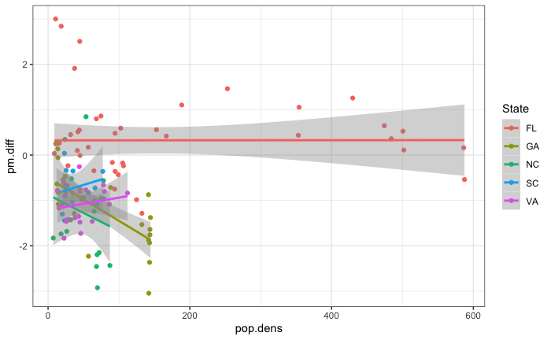

```r
qplot(pop.dens, pm.diff, data=by.site.final, color=State)+geom_smooth(method="lm")
```

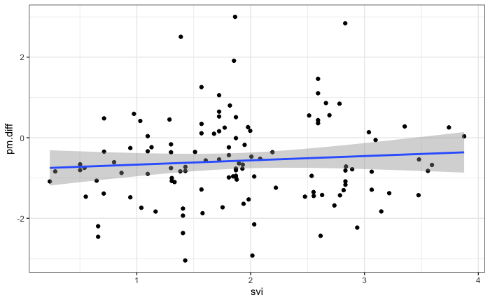

```r
qplot(svi, pm.diff, data=by.site.final)+geom_smooth(method="lm")
```

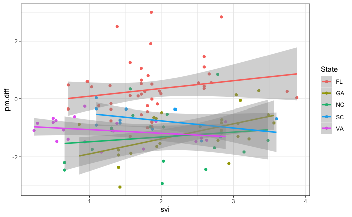

```r
qplot(svi, pm.diff, data=by.site.final, color=State)+geom_smooth(method="lm")
```

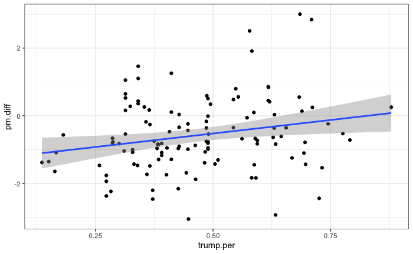

```r
qplot(trump.per, pm.diff, data=by.site.final)+geom_smooth(method="lm")
```

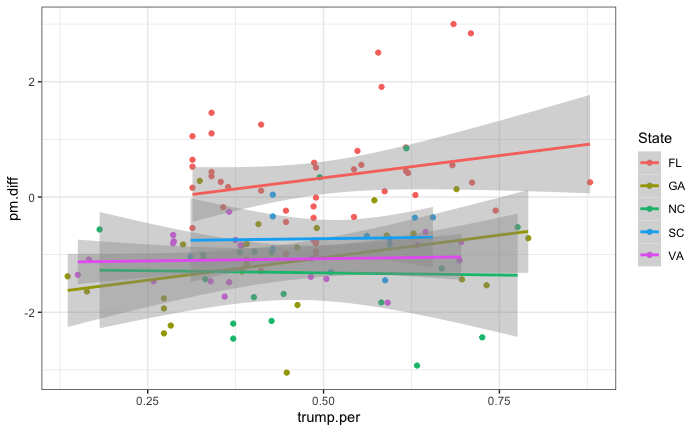

```r
qplot(trump.per, pm.diff, data=by.site.final, color=State)+geom_smooth(method="lm")
```

### Make a plot of the difference across the southeast US

```r
#Make the plot
theme_set(theme_bw())

#Make base map
world <- ne_countries(scale="medium", returnclass = "sf")
states <- st_as_sf(map("state", plot = FALSE, fill = TRUE))
states <- cbind(states, st_coordinates(st_centroid(states)))
```

```
st_centroid assumes attributes are constant over geometries of xst_centroid does not give correct centroids for longitude/latitude data
```

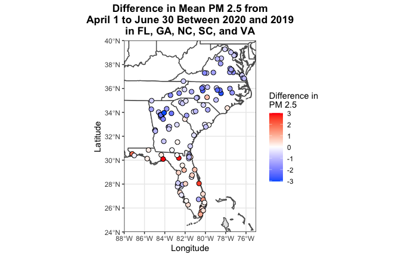

```r
(diff.map <-
  ggplot(data = world)+
    geom_sf() +
    geom_sf(data = states, fill="white")+
    geom_point(data=by.site.final, aes(x=SITE_LONGITUDE, y=SITE_LATITUDE, fill=(pm.diff)), size=2.5, pch=21)+
    scale_fill_gradient2(midpoint=0, mid="white", high="red", low="#0066ff", name="Difference in\nPM 2.5")+
    coord_sf(xlim = c(-88, -75), ylim = c(24, 40), expand = FALSE)+
    xlab("Longitude")+
    ylab("Latitude")+
    ggtitle("Difference in Mean PM 2.5 from\nApril 1 to June 30 Between 2020 and 2019\nin FL, GA, NC, SC, and VA")+
    theme(plot.title = element_text(hjust=0.5, face="bold")))
```

### Predictor Model Selection

```r
ols1 <- lm(pm.diff ~ pop.dens + trump.per + svi, data=by.site.final)
ols2 <- lm(pm.diff ~ pop.dens*State + trump.per + svi, data=by.site.final)
ols3 <- lm(pm.diff ~ pop.dens*State + trump.per*State + svi, data=by.site.final)
ols4 <- lm(pm.diff ~ pop.dens*State + trump.per + svi*State, data=by.site.final)
ols5 <- lm(pm.diff ~ pop.dens*State + trump.per*State + svi*State, data=by.site.final)
AIC(ols1, ols2, ols3, ols4, ols5)
```

|  | df | AIC |
| --- | --- | --- |
| ols1 | 5 | 348.4461 |
| ols2 | 13 | 296.0912 |
| ols3 | 17 | 299.4898 |
| ols4 | 17 | 300.9887 |
| ols5 | 21 | 305.0871 |

```r
anova(ols1, ols2, ols3, ols4, ols5)
```

```
Analysis of Variance Table

Model 1: pm.diff ~ pop.dens + trump.per + svi
Model 2: pm.diff ~ pop.dens * State + trump.per + svi
Model 3: pm.diff ~ pop.dens * State + trump.per * State + svi
Model 4: pm.diff ~ pop.dens * State + trump.per + svi * State
Model 5: pm.diff ~ pop.dens * State + trump.per * State + svi * State
  Res.Df     RSS Df Sum of Sq       F    Pr(>F)
1    116 117.919
2    108  66.711  8    51.208 10.1717 2.682e-10 ***
3    104  64.202  4     2.510  0.9970    0.4129
4    104  65.009  0    -0.807
5    100  62.929  4     2.080  0.8262    0.5115
---
Signif. codes:  0 ‘***’ 0.001 ‘**’ 0.01 ‘*’ 0.05 ‘.’ 0.1 ‘ ’ 1
```

```r
ols2.residuals <- residuals(ols2)
```

pop.dens*State + trump.per + svi is best model

### OLS Model and Variogram

Fit OLS and look at variogram

```r
L <- 50
d_max <- 2
d <- seq(0,d_max,length=L)
vg <- variog(coords=subset(by.site.final, select=c(SITE_LATITUDE, SITE_LONGITUDE)), data=ols2.residuals, uvec=d)
```

```
variog: computing omnidirectional variogram
```

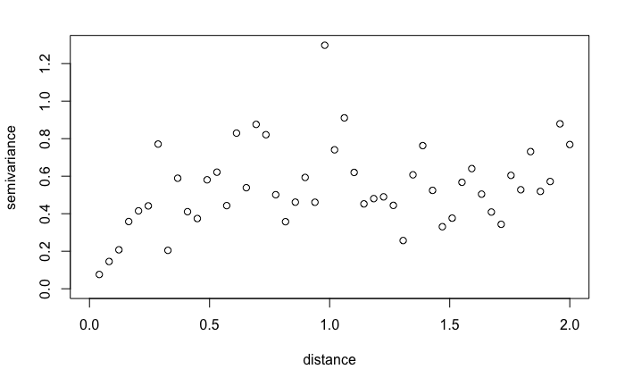

```r
plot(vg)
```

Check for non-stationarity

```r
L <- 50
d_max <- 4
d <- seq(0,d_max,length=L)

vg.by.state <- lapply(unique(by.site.final$State), FUN = function(x) variog(coords=by.site.final[by.site.final$State == x, colnames(by.site.final) %in% c("SITE_LONGITUDE", "SITE_LATITUDE")], data=ols2.residuals[by.site.final$State == x], uvec=d))
```

```
variog: computing omnidirectional variogram
variog: computing omnidirectional variogram
variog: computing omnidirectional variogram
variog: computing omnidirectional variogram
variog: computing omnidirectional variogram
```

```r
for (i in 1:length(unique(by.site.final$State))) {
  vg.by.state[[i]]$uvec <- unique(by.site.final$State)[i]
}

pdf("/Volumes/\ macOS\ -\ Data/Users/tyler/Documents/Fall\ 2020/ST533/midterm1/variogram_states.pdf", width=10, height=6)
par(mfrow=c(2,3))
lapply(vg.by.state, FUN = function(x) plot(x, main=x$uvec, ylim=c(0,2)))
```

```r
dev.off()
```

Check for anisotropy

```r
angles <- seq.default(from=0, to=pi, by=pi/6)
vg.by.angle <- lapply(angles, FUN = function(x) variog(coords=by.site.final[colnames(by.site.final) %in% c("SITE_LONGITUDE", "SITE_LATITUDE")], data=ols2.residuals, uvec=d, direction=x))
```

```
variog: computing variogram for direction = 0 degrees (0 radians)
        tolerance angle = 22.5 degrees (0.393 radians)
variog: computing variogram for direction = 30 degrees (0.524 radians)
        tolerance angle = 22.5 degrees (0.393 radians)
variog: computing variogram for direction = 60 degrees (1.047 radians)
        tolerance angle = 22.5 degrees (0.393 radians)
variog: computing variogram for direction = 90 degrees (1.571 radians)
        tolerance angle = 22.5 degrees (0.393 radians)
variog: computing variogram for direction = 120 degrees (2.094 radians)
        tolerance angle = 22.5 degrees (0.393 radians)
variog: computing variogram for direction = 150 degrees (2.618 radians)
        tolerance angle = 22.5 degrees (0.393 radians)
variog: computing variogram for direction = 180 degrees (3.142 radians)
        tolerance angle = 22.5 degrees (0.393 radians)
```

```r
pdf("/Volumes/\ macOS\ -\ Data/Users/tyler/Documents/Fall\ 2020/ST533/midterm1/variogram_degrees.pdf", width=10, height=6)
par(mfrow=c(2,4))
lapply(vg.by.angle, FUN = function(x) plot(x, main=paste(round(x$direction*180/pi,1), " degrees"), ylim=c(0,2)))
```

```r
dev.off()
```

### Fit MLE Models

Exponential correlation, with nugget and anisotropy

```r
#Scale continuous variables
by.site.final$pop.dens.scale <- scale(by.site.final$pop.dens, scale=T, center=T)
by.site.final$trump.per.scale <- scale(by.site.final$trump.per, scale=T, center=T)
by.site.final$svi.scale <- scale(by.site.final$svi, scale=T, center=T)

#Make a geodata object
by.site.final.geodat <- as.geodata(by.site.final, coords.col = 18:19, data.col = 22, covar.col = c(23,28:30), covar.names = c("State", "pop.dens.scale", "trump.per.scale", "svi.scale"))

#Initial parameters
init_tau2 <- 0.02
init_sig2 <- 0.5
init_phi <- 0.2
init_kappa <- 1.2
init_psiA <- 70/180*pi
init_psiR <- 1.1

#
(sp.fit.exp.nug.aniso <- likfit(geodata=by.site.final.geodat,
                      trend= ~ pop.dens.scale*State + trump.per.scale + svi.scale - 1 - pop.dens.scale,
                      fix.nugget=FALSE, nugget=init_tau2,
                      fix.psiA = FALSE,
                      psiA = init_psiA,
                      fix.psiR = FALSE,
                      psiR = init_psiR,
                      cov.model="exponential",
                      ini = c(init_sig2, init_phi)))
```

```
kappa not used for the exponential correlation function
---------------------------------------------------------------
likfit: likelihood maximisation using the function optim.
likfit: Use control() to pass additional
         arguments for the maximisation function.
        For further details see documentation for optim.
likfit: It is highly advisable to run this function several
        times with different initial values for the parameters.
likfit: WARNING: This step can be time demanding!
---------------------------------------------------------------
likfit: end of numerical maximisation.
likfit: estimated model parameters:
     beta0      beta1      beta2      beta3      beta4      beta5      beta6      beta7      beta8      beta9     beta10     beta11      tausq    sigmasq        phi       psiA       psiR
"  0.2905" " -1.3404" " -1.5645" " -0.6163" " -0.7041" "  0.1350" "  0.0463" "  0.0483" " -1.0045" " -0.7949" "  0.3287" "  0.8112" "  0.0483" "  0.5038" "  0.0402" "  1.3288" "189.4725"
Practical Range with cor=0.05 for asymptotic range: 0.120464

likfit: maximised log-likelihood = -127.2
```

```r
(sp.fit.exp.nug <- likfit(geodata=by.site.final.geodat,
                      trend= ~ pop.dens.scale*State + trump.per.scale + svi.scale - 1 - pop.dens.scale,
                      fix.nugget=FALSE, nugget=init_tau2,
                      cov.model="exponential",
                      ini = c(init_sig2, init_phi)))
```

```
kappa not used for the exponential correlation function
---------------------------------------------------------------
likfit: likelihood maximisation using the function optim.
likfit: Use control() to pass additional
         arguments for the maximisation function.
        For further details see documentation for optim.
likfit: It is highly advisable to run this function several
        times with different initial values for the parameters.
likfit: WARNING: This step can be time demanding!
---------------------------------------------------------------
likfit: end of numerical maximisation.
likfit: estimated model parameters:
    beta0     beta1     beta2     beta3     beta4     beta5     beta6     beta7     beta8     beta9    beta10    beta11     tausq   sigmasq       phi
" 0.4095" "-1.3411" "-1.4832" "-0.5323" "-0.8421" " 0.1221" " 0.0052" "-0.0282" "-1.1708" "-0.6834" " 0.5640" " 0.5829" " 0.0000" " 0.5735" " 0.1492"
Practical Range with cor=0.05 for asymptotic range: 0.4469378

likfit: maximised log-likelihood = -131.7
```

Exponential correlation, without nugget

```r
(sp.fit.exp.nonug <- likfit(geodata=by.site.final.geodat,
                            trend= ~ pop.dens.scale*State + trump.per.scale + svi.scale - 1 - pop.dens.scale,
                            fix.nugget=TRUE, nugget=0,
                            cov.model="exponential",
                            ini = c(init_sig2, init_phi)))
```

```
kappa not used for the exponential correlation function
---------------------------------------------------------------
likfit: likelihood maximisation using the function optimize.
likfit: Use control() to pass additional
         arguments for the maximisation function.
        For further details see documentation for optimize.
likfit: It is highly advisable to run this function several
        times with different initial values for the parameters.
likfit: WARNING: This step can be time demanding!
---------------------------------------------------------------
likfit: end of numerical maximisation.
likfit: estimated model parameters:
    beta0     beta1     beta2     beta3     beta4     beta5     beta6     beta7     beta8     beta9    beta10    beta11   sigmasq       phi
" 0.4095" "-1.3411" "-1.4832" "-0.5323" "-0.8421" " 0.1221" " 0.0052" "-0.0282" "-1.1708" "-0.6834" " 0.5640" " 0.5829" " 0.5736" " 0.1492"
Practical Range with cor=0.05 for asymptotic range: 0.4469689

likfit: maximised log-likelihood = -131.7
```

```r
(sp.fit.exp.nonug.aniso <- likfit(geodata=by.site.final.geodat,
                            trend= ~ pop.dens.scale*State + trump.per.scale + svi.scale - 1 - pop.dens.scale,
                            fix.nugget=TRUE, nugget=0,
                            fix.psiA = FALSE,
                            psiA = init_psiA,
                            fix.psiR = FALSE,
                            psiR = init_psiR,
                            cov.model="exponential",
                            ini = c(init_sig2, init_phi)))
```

```
kappa not used for the exponential correlation function
---------------------------------------------------------------
likfit: likelihood maximisation using the function optim.
likfit: Use control() to pass additional
         arguments for the maximisation function.
        For further details see documentation for optim.
likfit: It is highly advisable to run this function several
        times with different initial values for the parameters.
likfit: WARNING: This step can be time demanding!
---------------------------------------------------------------
likfit: end of numerical maximisation.
likfit: estimated model parameters:
    beta0     beta1     beta2     beta3     beta4     beta5     beta6     beta7     beta8     beta9    beta10    beta11   sigmasq       phi      psiA      psiR
" 0.3141" "-1.3423" "-1.5666" "-0.6119" "-0.7262" " 0.1344" " 0.0417" " 0.0364" "-1.0358" "-0.7990" " 0.3398" " 0.7772" " 0.5492" " 0.0561" " 1.3446" "22.3700"
Practical Range with cor=0.05 for asymptotic range: 0.16798

likfit: maximised log-likelihood = -127.9
```

Matern correlation, with nugget

```r
(sp.fit.matern.nug <- likfit(geodata=by.site.final.geodat,
                             trend= ~ pop.dens.scale*State + trump.per.scale + svi.scale - 1 - pop.dens.scale,
                            fix.nugget=FALSE, nugget=init_tau2,
                            fix.kappa=FALSE, kappa = init_kappa,
                            cov.model="matern",
                            ini = c(init_sig2, init_phi)))
```

```
---------------------------------------------------------------
likfit: likelihood maximisation using the function optim.
likfit: Use control() to pass additional
         arguments for the maximisation function.
        For further details see documentation for optim.
likfit: It is highly advisable to run this function several
        times with different initial values for the parameters.
likfit: WARNING: This step can be time demanding!
---------------------------------------------------------------
likfit: end of numerical maximisation.
likfit: estimated model parameters:
    beta0     beta1     beta2     beta3     beta4     beta5     beta6     beta7     beta8     beta9    beta10    beta11     tausq   sigmasq       phi     kappa
" 0.3800" "-1.3350" "-1.5625" "-0.6117" "-0.8132" " 0.1433" " 0.0032" "-0.0044" "-1.1443" "-0.8029" " 0.3504" " 0.6438" " 0.0450" " 0.5325" " 0.0176" "17.4477"
Practical Range with cor=0.05 for asymptotic range: 0.2586398

likfit: maximised log-likelihood = -131.1
```

```r
(sp.fit.matern.nug.aniso <- likfit(geodata=by.site.final.geodat,
                             trend= ~ pop.dens.scale*State + trump.per.scale + svi.scale - 1 - pop.dens.scale,
                            fix.nugget=FALSE, nugget=init_tau2,
                            fix.kappa=FALSE, kappa = init_kappa,
                            fix.psiA = FALSE,
                            psiA = init_psiA,
                            fix.psiR = FALSE,
                            psiR = init_psiR,
                            cov.model="matern",
                            ini = c(init_sig2, init_phi)))
```

```
---------------------------------------------------------------
likfit: likelihood maximisation using the function optim.
likfit: Use control() to pass additional
         arguments for the maximisation function.
        For further details see documentation for optim.
likfit: It is highly advisable to run this function several
        times with different initial values for the parameters.
likfit: WARNING: This step can be time demanding!
---------------------------------------------------------------
likfit: end of numerical maximisation.
likfit: estimated model parameters:
    beta0     beta1     beta2     beta3     beta4     beta5     beta6     beta7     beta8     beta9    beta10    beta11     tausq   sigmasq       phi     kappa      psiA      psiR
" 0.3006" "-1.3358" "-1.5746" "-0.6210" "-0.7241" " 0.1375" " 0.0424" " 0.0412" "-1.0224" "-0.8132" " 0.3201" " 0.7850" " 0.1323" " 0.4185" " 0.0160" " 6.5220" " 1.3207" "49.7759"
Practical Range with cor=0.05 for asymptotic range: 0.1463685

likfit: maximised log-likelihood = -126.7
```

Matern correlation, without nugget

```r
(sp.fit.matern.nonug <- likfit(geodata=by.site.final.geodat,
                                trend= ~ pop.dens.scale*State + trump.per.scale + svi.scale - 1 - pop.dens.scale,
                                fix.nugget=TRUE, nugget=0,
                                fix.kappa=FALSE, kappa = init_kappa,
                                cov.model="matern",
                                ini = c(init_sig2, init_phi)))
```

```
---------------------------------------------------------------
likfit: likelihood maximisation using the function optim.
likfit: Use control() to pass additional
         arguments for the maximisation function.
        For further details see documentation for optim.
likfit: It is highly advisable to run this function several
        times with different initial values for the parameters.
likfit: WARNING: This step can be time demanding!
---------------------------------------------------------------
likfit: end of numerical maximisation.
likfit: estimated model parameters:
    beta0     beta1     beta2     beta3     beta4     beta5     beta6     beta7     beta8     beta9    beta10    beta11   sigmasq       phi     kappa
" 0.3945" "-1.3389" "-1.5230" "-0.5848" "-0.8337" " 0.1364" "-0.0013" "-0.0171" "-1.1665" "-0.7398" " 0.4228" " 0.6127" " 0.5804" " 0.0689" " 1.4684"
Practical Range with cor=0.05 for asymptotic range: 0.323778

likfit: maximised log-likelihood = -131.2
```

```r
(sp.fit.matern.nonug.aniso <- likfit(geodata=by.site.final.geodat,
                                trend= ~ pop.dens.scale*State + trump.per.scale + svi.scale - 1 - pop.dens.scale,
                                fix.nugget=TRUE, nugget=0,
                                fix.kappa=FALSE, kappa = init_kappa,
                                fix.psiA = FALSE,
                                psiA = init_psiA,
                                fix.psiR = FALSE,
                                psiR = init_psiR,
                                cov.model="matern",
                                ini = c(init_sig2, init_phi)))
```

```
---------------------------------------------------------------
likfit: likelihood maximisation using the function optim.
likfit: Use control() to pass additional
         arguments for the maximisation function.
        For further details see documentation for optim.
likfit: It is highly advisable to run this function several
        times with different initial values for the parameters.
likfit: WARNING: This step can be time demanding!
---------------------------------------------------------------
likfit: end of numerical maximisation.
likfit: estimated model parameters:
     beta0      beta1      beta2      beta3      beta4      beta5      beta6      beta7      beta8      beta9     beta10     beta11    sigmasq        phi      kappa       psiA       psiR
"  0.2894" " -1.3408" " -1.5637" " -0.6162" " -0.7024" "  0.1349" "  0.0466" "  0.0489" " -1.0027" " -0.7936" "  0.3290" "  0.8135" "  0.5523" "  0.0425" "  0.3807" "  1.3288" "204.9873"
Practical Range with cor=0.05 for asymptotic range: 0.1134711

likfit: maximised log-likelihood = -127.2
```

Compare models with AIC

```r
AIC(sp.fit.exp.nug, sp.fit.exp.nonug, sp.fit.matern.nug, sp.fit.matern.nonug, sp.fit.exp.nug.aniso, sp.fit.exp.nonug.aniso, sp.fit.matern.nug.aniso, sp.fit.matern.nonug.aniso)
```

|  | df | AIC |
| --- | --- | --- |
| sp.fit.exp.nug | 15 | 293.3158 |
| sp.fit.exp.nonug | 14 | 291.3158 |
| sp.fit.matern.nug | 16 | 294.2610 |
| sp.fit.matern.nonug | 15 | 292.3863 |
| sp.fit.exp.nug.aniso | 17 | 288.3138 |
| sp.fit.exp.nonug.aniso | 16 | 287.7008 |
| sp.fit.matern.nug.aniso | 18 | 289.3255 |
| sp.fit.matern.nonug.aniso | 17 | 288.3788 |

It looks like the exponential model without a nugget term and with anisotropy is best supported.

```r
summary(sp.fit.exp.nonug.aniso)
```

```
Summary of the parameter estimation
-----------------------------------
Estimation method: maximum likelihood

Parameters of the mean component (trend):
  beta0   beta1   beta2   beta3   beta4   beta5   beta6   beta7   beta8   beta9  beta10  beta11
 0.3141 -1.3423 -1.5666 -0.6119 -0.7262  0.1344  0.0417  0.0364 -1.0358 -0.7990  0.3398  0.7772

Parameters of the spatial component:
   correlation function: exponential
      (estimated) variance parameter sigmasq (partial sill) =  0.5492
      (estimated) cor. fct. parameter phi (range parameter)  =  0.0561
   anisotropy parameters:
      (estimated) anisotropy angle = 1.345  ( 77 degrees )
      (estimated) anisotropy ratio = 22.37

Parameter of the error component:
      (fixed) nugget = 0

Transformation parameter:
      (fixed) Box-Cox parameter = 1 (no transformation)

Practical Range with cor=0.05 for asymptotic range: 0.16798

Maximised Likelihood:
   log.L n.params      AIC      BIC
"-127.9"     "16"  "287.7"  "332.3"

non spatial model:
   log.L n.params      AIC      BIC
  "-135"     "13"  "296.1"  "332.3"

Call:
likfit(geodata = by.site.final.geodat, trend = ~pop.dens.scale *
    State + trump.per.scale + svi.scale - 1 - pop.dens.scale,
    ini.cov.pars = c(init_sig2, init_phi), fix.nugget = TRUE,
    nugget = 0, fix.psiA = FALSE, psiA = init_psiA, fix.psiR = FALSE,
    psiR = init_psiR, cov.model = "exponential")
```

```r
sp.fit.exp.nonug.aniso$cov.pars
```

```
[1] 0.54919275 0.05607381
```

### Set up Kriging prediction

Make a grid of points in spatial range

```r
#Make predictions coordinates
```

```
There were 24 warnings (use warnings() to see them)
```

```r
pred.coords <- data.frame(
  x=seq.default(from=(min(by.site.final$SITE_LONGITUDE)), to=max(by.site.final$SITE_LONGITUDE), length.out = 100),
  y=seq.default(from=(min(by.site.final$SITE_LATITUDE)), to=max(by.site.final$SITE_LATITUDE), length.out = 100)
)
#Make a grid
pred.grid <- expand.grid(pred.coords)
#Subset to only be inside US
in.usa <- map.where(database = "usa", pred.grid[,1], pred.grid[,2])
pred.grid.us <- pred.grid[!is.na(in.usa),]
```

Make a column for state that each point is in

```r
#Florida
m.fl <- map("state", "florida", fill=T, plot=F, resolution = 0)
in.fl <- map.where(database = m.fl, pred.grid.us[,1], pred.grid.us[,2])
pred.grid.fl <- pred.grid.us[!is.na(in.fl),]
pred.grid.fl$State <- "FL"
#Georgia
m.ga <- map("state", "georgia", fill=T, plot=F, resolution = 0)
in.ga <- map.where(database = m.ga, pred.grid.us[,1], pred.grid.us[,2])
pred.grid.ga <- pred.grid.us[!is.na(in.ga),]
pred.grid.ga$State <- "GA"
#North Carolina
m.nc <- map("state", "north carolina", fill=T, plot=F, resolution = 0)
in.nc <- map.where(database = m.nc, pred.grid.us[,1], pred.grid.us[,2])
pred.grid.nc <- pred.grid.us[!is.na(in.nc),]
pred.grid.nc$State <- "NC"
#South Carolina
m.sc <- map("state", "south carolina", fill=T, plot=F, resolution = 0)
in.sc <- map.where(database = m.sc, pred.grid.us[,1], pred.grid.us[,2])
pred.grid.sc <- pred.grid.us[!is.na(in.sc),]
pred.grid.sc$State <- "SC"
#Virginia
m.va <- map("state", "virginia", fill=T, plot=F, resolution = 0)
in.va <- map.where(database = m.va, pred.grid.us[,1], pred.grid.us[,2])
pred.grid.va <- pred.grid.us[!is.na(in.va),]
pred.grid.va$State <- "VA"

#Recombine into one dataframe
pred.grid.us.st <- as.data.frame(
  rbind(
    pred.grid.fl,
    pred.grid.ga,
    pred.grid.nc,
    pred.grid.sc,
    pred.grid.va
  )
)
```

Grab population density at these points

```r
states <- c("FL", "GA", "NC", "SC", "VA")
starts <- as.matrix(cbind(rbind(fl.start, ga.start, nc.start, sc.start, va.start), as.integer(c(nrow(fl.pop), nrow(ga.pop), nrow(nc.pop), nrow(sc.pop), nrow(va.pop)))))
starts.df <- as.data.frame(cbind(starts, states))
colnames(starts.df) <- c("lon", "lat", "nrow", "state")

#Loop over states and grab the proper indices within each state's grid for the target cell (the one where the station is located). Note that the coordinates of the cells are the lower left corner, so we use floor to round down to them.
#What we do is for both longitide and latitude, we find the difference in degrees between the baseline cell of that state's grid (lower left) and the coordinates of the measurement station, then divide that difference by the size of each cell, to get number of cells from the grid baseline. We round down since the grid cells are referenced by lower lefthand corner. Do this for each state and combine them into a list of "target" grids for each state.
cells.pred <- list(NULL)
for (i in 1:length(states)) {
  cells.pred[[i]] <- cbind(floor((pred.grid.us.st$x[pred.grid.us.st$State == states[i]] - starts[i,1])/grid.inc), floor((pred.grid.us.st$y[pred.grid.us.st$State == states[i]] - starts[i,2])/grid.inc))
}
#Turn this into a dataframe
cells.pred.df <- as.data.frame(do.call('rbind', cells.pred))
#Add a state column
cells.pred.df$state <- pred.grid.us.st$State
#Make list of the raw grid data for the states
grids.pred <- list(
  fl.pop, ga.pop, nc.pop, sc.pop, va.pop
)
#Give the grid list items the names of the states so we can grab them by name
names(grids.pred) <- states

#Loop over the desired grid cells, find all cells within 10 cells of the target cell (a square with sides of 630 arc seconds, or 0.175 arc degree, or about 10.5 miles centered on the target grid; or roughly a circle with radius 5.5 miles around the station)
pred.grid.us.st$pop.dens <- NULL
cell.feather <- 100
for (i in 1:nrow(cells.pred.df)) { #Loop over the rows of the cell indices desired
  pred.grid.us.st$pop.dens[i] <-
    mean(
      as.matrix(
        #Subset the grid list to get the proper state's grid
        grids.pred[[names(grids.pred)[names(grids.pred) == cells.pred.df$state[i]]]]
          #Subset the rows of the grid based on the cell number found in the cells.df column, and keep in mind that we have to work backwards for the rows because the cells start in the bottom left for the grid, so subract the desired cell row from the number of total cells.
          #When you jitter by 10 cells, account for the fact that we may be less than 10 cells away from the edge of the grid, so take the min of 10 or the difference between the current row and the total number of rows. This is the lower bound for the rows, so subtract 10 (or min)
          [(as.integer(starts.df$nrow[starts.df$state == cells.pred.df$state[i]]) - cells.pred.df$V2[i] - min(cell.feather, as.integer(starts.df$nrow[starts.df$state == cells.pred.df$state[i]]) - cells.pred.df$V2[i]))
            #This is the upper bound for the rows, so add 10 (or min)
            :(as.integer(starts.df$nrow[starts.df$state == cells.pred.df$state[i]]) - cells.pred.df$V2[i] + min(cell.feather, as.integer(starts.df$nrow[starts.df$state == cells.pred.df$state[i]]) - cells.pred.df$V2[i])),
            #The columns are easier because the indices are in the same order as the grid, so we just need to subtract the lower and upper bound as 10 or min.
            (cells.pred.df$V1[i] - min(cell.feather, cells.pred.df$V1[i], ncol(grids.pred[[names(grids.pred)[names(grids.pred) == cells.pred.df$state[i]]]]) - cells.pred.df$V1[i]))
            :(cells.pred.df$V1[i] + min(cell.feather, cells.pred.df$V1[i], ncol(grids.pred[[names(grids.pred)[names(grids.pred) == cells.pred.df$state[i]]]]) - cells.pred.df$V1[i]))]
      ), #Return a matrix
    na.rm = T) #Find the mean of all of the cells, excluding NAs
}
```

Make a column for counties

```r
#Grab names of counties
fl.counties <- map("county", "florida", fill=T, plot=F, resolution=0)
fl.counties.uniq <- fl.counties$names
ga.counties <- map("county", "georgia", fill=T, plot=F, resolution=0)
ga.counties.uniq <- ga.counties$names
nc.counties <- map("county", "north carolina", fill=T, plot=F, resolution=0)
nc.counties.uniq <- nc.counties$names
sc.counties <- map("county", "south carolina", fill=T, plot=F, resolution=0)
sc.counties.uniq <- sc.counties$names
va.counties <- map("county", "virginia", fill=T, plot=F, resolution=0)
va.counties.uniq <- va.counties$names

#Grab maps/coordinates for each county in each state into a list
fl.counties.coords <- lapply(fl.counties.uniq, FUN = function(x) map("county", x, fill=T, plot=F, resolution = 0))
ga.counties.coords <- lapply(ga.counties.uniq, FUN = function(x) map("county", x, fill=T, plot=F, resolution = 0))
nc.counties.coords <- lapply(nc.counties.uniq, FUN = function(x) map("county", x, fill=T, plot=F, resolution = 0))
sc.counties.coords <- lapply(sc.counties.uniq, FUN = function(x) map("county", x, fill=T, plot=F, resolution = 0))
va.counties.coords <- lapply(va.counties.uniq, FUN = function(x) map("county", x, fill=T, plot=F, resolution = 0))

#Name the list items for the county they belong to
names(fl.counties.coords) <- fl.counties.uniq
names(ga.counties.coords) <- ga.counties.uniq
names(nc.counties.coords) <- nc.counties.uniq
names(sc.counties.coords) <- sc.counties.uniq
names(va.counties.coords) <- va.counties.uniq


####Florida
#Go through each state and loop over the counties and grab the county name that each point belongs to
pred.grid.fl.county.list <- list(NULL)
for (i in 1:length(names(fl.counties.coords))) {                                #Loop over the names of the list items of the counties.coords, which contains the coordinates for the ith county in the state
  temp <- map.where(fl.counties.coords[[i]], pred.grid.fl$x, pred.grid.fl$y)    #Use map.where to get a subset of the prediction points in county i
  if(nrow(pred.grid.fl[!is.na(temp),] > 0)) {                                   #If the subset has more than 0 rows, then put the subset as a list item into a new list
    pred.grid.fl.county.list[[i]] <- pred.grid.fl[!is.na(temp),]
    pred.grid.fl.county.list[[i]]$county <- names(fl.counties.coords)[i]        #Name the new list item according to the county that the points came from
  }
}
#Extract list into a dataframe
pred.grid.fl.county <- do.call('rbind', pred.grid.fl.county.list)
#Remove "state," and capitalize county name
pred.grid.fl.county$county <- sapply(pred.grid.fl.county$county, FUN = function(x) paste0(toupper(strsplit(split = "", gsub('florida,', '', x))[[1]][1]), paste(as.vector(strsplit(split = "", gsub('florida,', '', x))[[1]][-c(1)]), collapse = "")))
#Make state_county column
pred.grid.fl.county$state_county <- paste(pred.grid.fl.county$State, pred.grid.fl.county$county, sep="_")

####Georgia
#Go through each state and loop over the counties and grab the county name that each point belongs to
pred.grid.ga.county.list <- list(NULL)
for (i in 1:length(names(ga.counties.coords))) {                                #Loop over the names of the list items of the counties.coords, which contains the coordinates for the ith county in the state
  temp <- map.where(ga.counties.coords[[i]], pred.grid.ga$x, pred.grid.ga$y)    #Use map.where to get a subset of the prediction points in county i
  if(nrow(pred.grid.ga[!is.na(temp),] > 0)) {                                   #If the subset has more than 0 rows, then put the subset as a list item into a new list
    pred.grid.ga.county.list[[i]] <- pred.grid.ga[!is.na(temp),]
    pred.grid.ga.county.list[[i]]$county <- names(ga.counties.coords)[i]        #Name the new list item according to the county that the points came from
  }
}
#Extract list into a dataframe
pred.grid.ga.county <- do.call('rbind', pred.grid.ga.county.list)
#Remove "state," and capitalize county name
pred.grid.ga.county$county <- sapply(pred.grid.ga.county$county, FUN = function(x) paste0(toupper(strsplit(split = "", gsub('georgia,', '', x))[[1]][1]), paste(as.vector(strsplit(split = "", gsub('georgia,', '', x))[[1]][-c(1)]), collapse = "")))
#Make state_county column
pred.grid.ga.county$state_county <- paste(pred.grid.ga.county$State, pred.grid.ga.county$county, sep="_")

####North Carolina
#Go through each state and loop over the counties and grab the county name that each point belongs to
pred.grid.nc.county.list <- list(NULL)
for (i in 1:length(names(nc.counties.coords))) {                                #Loop over the names of the list items of the counties.coords, which contains the coordinates for the ith county in the state
  temp <- map.where(nc.counties.coords[[i]], pred.grid.nc$x, pred.grid.nc$y)    #Use map.where to get a subset of the prediction points in county i
  if(nrow(pred.grid.nc[!is.na(temp),] > 0)) {                                   #If the subset has more than 0 rows, then put the subset as a list item into a new list
    pred.grid.nc.county.list[[i]] <- pred.grid.nc[!is.na(temp),]
    pred.grid.nc.county.list[[i]]$county <- names(nc.counties.coords)[i]        #Name the new list item according to the county that the points came from
  }
}
#Extract list into a dataframe
pred.grid.nc.county <- do.call('rbind', pred.grid.nc.county.list)
#Remove "state," and capitalize county name
pred.grid.nc.county$county <- sapply(pred.grid.nc.county$county, FUN = function(x) paste0(toupper(strsplit(split = "", gsub('north carolina,', '', x))[[1]][1]), paste(as.vector(strsplit(split = "", gsub('north carolina,', '', x))[[1]][-c(1)]), collapse = "")))
#Make state_county column
pred.grid.nc.county$state_county <- paste(pred.grid.nc.county$State, pred.grid.nc.county$county, sep="_")

####South Carolina
#Go through each state and loop over the counties and grab the county name that each point belongs to
pred.grid.sc.county.list <- list(NULL)
for (i in 1:length(names(sc.counties.coords))) {                                #Loop over the names of the list items of the counties.coords, which contains the coordinates for the ith county in the state
  temp <- map.where(sc.counties.coords[[i]], pred.grid.sc$x, pred.grid.sc$y)    #Use map.where to get a subset of the prediction points in county i
  if(nrow(pred.grid.sc[!is.na(temp),] > 0)) {                                   #If the subset has more than 0 rows, then put the subset as a list item into a new list
    pred.grid.sc.county.list[[i]] <- pred.grid.sc[!is.na(temp),]
    pred.grid.sc.county.list[[i]]$county <- names(sc.counties.coords)[i]        #Name the new list item according to the county that the points came from
  }
}
#Extract list into a dataframe
pred.grid.sc.county <- do.call('rbind', pred.grid.sc.county.list)
#Remove "state," and capitalize county name
pred.grid.sc.county$county <- sapply(pred.grid.sc.county$county, FUN = function(x) paste0(toupper(strsplit(split = "", gsub('south carolina,', '', x))[[1]][1]), paste(as.vector(strsplit(split = "", gsub('south carolina,', '', x))[[1]][-c(1)]), collapse = "")))
#Make state_county column
pred.grid.sc.county$state_county <- paste(pred.grid.sc.county$State, pred.grid.sc.county$county, sep="_")

####Virginia
#Go through each state and loop over the counties and grab the county name that each point belongs to
pred.grid.va.county.list <- list(NULL)
for (i in 1:length(names(va.counties.coords))) {                                #Loop over the names of the list items of the counties.coords, which contains the coordinates for the ith county in the state
  temp <- map.where(va.counties.coords[[i]], pred.grid.va$x, pred.grid.va$y)    #Use map.where to get a subset of the prediction points in county i
  if(nrow(pred.grid.va[!is.na(temp),] > 0)) {                                   #If the subset has more than 0 rows, then put the subset as a list item into a new list
    pred.grid.va.county.list[[i]] <- pred.grid.va[!is.na(temp),]
    pred.grid.va.county.list[[i]]$county <- names(va.counties.coords)[i]        #Name the new list item according to the county that the points came from
  }
}
#Extract list into a dataframe
pred.grid.va.county <- do.call('rbind', pred.grid.va.county.list)
#Remove "state," and capitalize county name
pred.grid.va.county$county <- sapply(pred.grid.va.county$county, FUN = function(x) paste0(toupper(strsplit(split = "", gsub('virginia,', '', x))[[1]][1]), paste(as.vector(strsplit(split = "", gsub('virginia,', '', x))[[1]][-c(1)]), collapse = "")))
#Make state_county column
pred.grid.va.county$state_county <- paste(pred.grid.va.county$State, pred.grid.va.county$county, sep="_")

###Combine them into one df
pred.grid.counties <- rbind(pred.grid.fl.county, pred.grid.ga.county, pred.grid.nc.county, pred.grid.sc.county, pred.grid.va.county)
pred.grid.final <- merge(pred.grid.counties, pred.grid.us.st, by=c("x", "y"), all.x=F, all.y=F, no.dups=T)

#Remove weird :main and other things from county name
pred.grid.final$state_county <- gsub('\\:main', '', pred.grid.final$state_county)

#Capitalize second word in each name with a space
simpleCap <- function(x) {
  s <- strsplit(x, " ")[[1]]
  paste(toupper(substring(s, 1,1)), substring(s, 2),
      sep="", collapse=" ")
}

pred.grid.final$state_county[grep(" ", pred.grid.final$state_county)] <- as.character(sapply(pred.grid.final$state_county[grep(" ", pred.grid.final$state_county)], simpleCap))

#Make 'Of' into 'of' and 'And' into 'and'
pred.grid.final$state_county <- gsub('And', 'and', gsub('Of', 'of', pred.grid.final$state_county))
#Make James City into James
pred.grid.final$state_county <- gsub('De Kalb', 'DeKalb', gsub('De Soto', 'DeSoto', gsub('Mcintosh', 'McIntosh', gsub('St ', 'St. ', gsub('Miami-dade', 'Miami-Dade', gsub('Charles City', 'Charles', gsub('James City', 'James', pred.grid.final$state_county)))))))
```

Add SVI data to pred.grid.final

```r
#In VA, there's Franklin City and Franklin listed as counties. Remove Franklin City for now
svi3 <- svi2[svi2$COUNTY != "Franklin City",]

# for (i in 1:nrow(pred.grid.final)) {
#   pred.grid.final$svi[i] <- svi3$SPL_THEME1[tolower(svi3$state_county) == tolower(pred.grid.final$state_county)[i]]
# }
pred.grid.svi.list <- NULL
pred.grid.svi.list <- as.numeric(as.character(sapply(pred.grid.final$state_county, FUN = function(x) svi3$SPL_THEME1[tolower(svi3$state_county) == tolower(x)])))
pred.grid.final$svi <- pred.grid.svi.list
```

Add trump.per to pred.grid.final

```r
#In VA, there's Franklin City and Franklin listed as counties. Remove Franklin City for now
pres3 <- pres2[!(pres2$fips %in% c(51620, 51515)),]
#Make James City into James
pres3$state_county <- gsub('James City', 'James', pres3$state_county)

pred.grid.trump.per.list <- NULL
pred.grid.trump.per.list <- as.numeric(as.character(sapply(pred.grid.final$state_county, FUN = function(x) pres3$trump.per[tolower(pres3$state_county) == tolower(x)])))
pred.grid.final$trump.per <- pred.grid.trump.per.list
# pred.grid.trump.per.list.length <- sapply(pred.grid.trump.per.list, length)
# pred.grid.trump.per.list.length[pred.grid.trump.per.list.length < 1]
```

Make some final cleanups

```r
#Drop state.x and state.y
pred.grid.final$State <- pred.grid.final$State.x
pred.grid.final <- subset(pred.grid.final, select  = -c(State.x, State.y))

#Scale continuous variables
pred.grid.final$pop.dens.scale <- scale(pred.grid.final$pop.dens, scale=T, center=T)
pred.grid.final$trump.per.scale <- scale(pred.grid.final$trump.per, scale=T, center=T)
pred.grid.final$svi.scale <- scale(pred.grid.final$svi, scale=T, center=T)

#Remove any Lat Lon combinations that are duplicated
pred.grid.final <- pred.grid.final[-which(duplicated(paste(pred.grid.final$x, pred.grid.final$y, sep="_"))),]
```

Combine the prediction locations with site locations so we can get predictions at the sites as well

```r
by.site.final.coords <- by.site.final.geodat$coords
pred.grid.final.coords <- cbind(pred.grid.final$y, pred.grid.final$x)
colnames(by.site.final.coords) <- c("y", "x")

all.locations <- rbind(
  by.site.final.coords,
  pred.grid.final.coords
)

#Remove rows 422, 423, 450, and 451 because too close to a station
# all.locations <- all.locations[-c(445,446),]
```

Combine the prediction covariates with the site covariates so we can get predictions at both

```r
by.site.final.covariates <- subset(by.site.final, select = c(pop.dens.scale, trump.per.scale, svi.scale, State))
pred.grid.final.covariates <- subset(pred.grid.final, select = c(pop.dens.scale, trump.per.scale, svi.scale, State))


all.covariates <- rbind(
  by.site.final.covariates,
  pred.grid.final.covariates
)

#Remove rows 422, 423, 450, and 451 because too close to a station
# all.covariates <- all.covariates[-c(445,446),]
```

Try to find prediction sites that are too close to each other

```r
# all.loc.dist <- as.matrix(dist(all.locations, diag = T, upper = T))
# diag(all.loc.dist) <- NA
# all.loc.dist.lower <- all.loc.dist[lower.tri(all.loc.dist)]
#
# zeros <- do.call('c', apply(all.loc.dist, 1, FUN = function(x) x[x < 0.2]))
# zeros[!is.na(zeros)]
# ?apply()
#
# order(zeros, decreasing = T)
#
#
# check.zero <- 1:nrow(all.loc.dist)
# for (i in 1:nrow(all.loc.dist)) {
#   check.zero[i] <- ifelse(length(which(all.loc.dist[i,] == 0)) > 0, which(all.loc.dist[i,] == 0), NA)
# }
# which(!is.na(check.zero))
#
#
# pred.grid.final.dist <- as.matrix(dist(pred.grid.final.coords, diag=T, upper=T, method="euclidean"))
# diag(pred.grid.final.dist) <- NA
#
# check.zero <- 1:nrow(pred.grid.final.dist)
# for (i in 1:nrow(pred.grid.final.dist)) {
#   check.zero[i] <- ifelse(length(which(pred.grid.final.dist[i,] == 0)) > 0, which(pred.grid.final.dist[i,] == 0), NA)
# }
# which(!is.na(check.zero))
# check.zero[!is.na(check.zero)]
# check.zero[273]
#
# pred.grid.final.dist[272:273,]
# (pred.grid.final[272:273,])
#
# pred.grid.test <- pred.grid.final[-272,]
# pred.grid.test[271:273,]
```

### Fit Bayesian model with geoR using ansiotropy parameters above

```r
sp.fit.exp.nonug.aniso.bayes <- krige.bayes(geodata = by.site.final.geodat,
                                    locations = all.locations,
                                    model = model.control(
                                      trend.d = ~ pop.dens.scale*State + trump.per.scale + svi.scale - 1 - pop.dens.scale,
                                      trend.l = ~ all.covariates$pop.dens.scale*all.covariates$State + all.covariates$trump.per.scale + all.covariates$svi.scale,
                                      cov.model="exponential",
                                      aniso.pars = sp.fit.exp.nonug.aniso$aniso.pars),
                                    prior = prior.control(
                                      beta.prior = "normal",
                                      beta = rep(0,12),
                                      beta.var.std = 10*diag(12),
                                      sigmasq.prior = "sc.inv.chisq",
                                      sigmasq = sp.fit.exp.nonug.aniso$cov.pars[1],
                                      df.sigmasq = 2,
                                      phi.prior = "squared.reciprocal",
                                      # phi.discrete = seq.default(from=0,to=0.4,by=0.01),
                                      # phi = sp.fit.exp.nonug.aniso$cov.pars[2],
                                      tausq.rel.prior= "uniform",
                                      tausq.rel.discrete = seq.default(from=0,to=10,by=0.2)
                                      ),
                                    output = output.control(
                                      n.posterior = 10000,
                                      mean.var = T,
                                      sim.means = T,
                                      sim.vars = T,
                                      simulations.predictive = T)
                                    )
```

[output not shown]

[output cut: 53 more lines]

```r
# save.image(file="/Volumes/\ macOS\ -\ Data/Users/tyler/Documents/Fall\ 2020/ST533/midterm1/rdata/600_preds.Rdata")
```

Extract the beta parameter summary

```r
bayes.beta.sum <- as.data.frame(sp.fit.exp.nonug.aniso.bayes$posterior$beta$summary)
```

```
There were 45 warnings (use warnings() to see them)
```

```r
rownames(bayes.beta.sum) <- colnames(model.matrix(pm.diff ~ pop.dens.scale*State + trump.per.scale + svi.scale - 1 - pop.dens.scale, data=by.site.final))
```

Extract the posterior samples and generate a figure

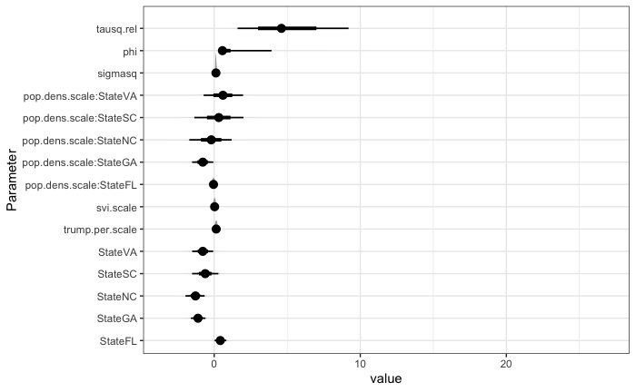

```r
#Extract posterior samples for all parameters
sp.fit.exp.nonug.aniso.bayes.samp <- sp.fit.exp.nonug.aniso.bayes$posterior$sample
colnames(sp.fit.exp.nonug.aniso.bayes.samp)[1:12] <- colnames(model.matrix(pm.diff ~ pop.dens.scale*State + trump.per.scale + svi.scale - 1 - pop.dens.scale, data=by.site.final))
#Melt the data for ggplot
sp.fit.exp.nonug.aniso.bayes.samp.melt <- melt(sp.fit.exp.nonug.aniso.bayes.samp)
#Make a halfeye figure
ggplot(sp.fit.exp.nonug.aniso.bayes.samp.melt, aes(x=value, y=variable))+
  geom_halfeyeh()+
  theme_bw()+
  ylab("Parameter")
```

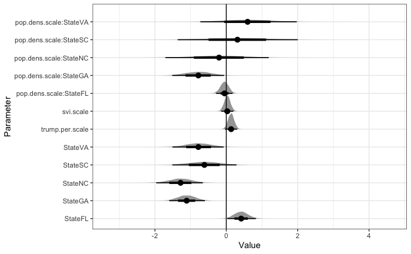

```r
#Make a halfeye figure for just betas
sp.fit.exp.nonug.ansio.bayes.samp.betas <- sp.fit.exp.nonug.aniso.bayes$posterior$sample
sp.fit.exp.nonug.ansio.bayes.samp.betas <- sp.fit.exp.nonug.ansio.bayes.samp.betas[,grep('beta', colnames(sp.fit.exp.nonug.ansio.bayes.samp.betas))]
colnames(sp.fit.exp.nonug.ansio.bayes.samp.betas) <- colnames(model.matrix(pm.diff ~ pop.dens.scale*State + trump.per.scale + svi.scale - 1 - pop.dens.scale, data=by.site.final))
#Melt the data for ggplot
sp.fit.exp.nonug.ansio.bayes.samp.betas.melt <- melt(sp.fit.exp.nonug.ansio.bayes.samp.betas)
#Make a halfeye figure
ggplot(sp.fit.exp.nonug.ansio.bayes.samp.betas.melt, aes(x=value, y=variable))+
  geom_halfeyeh()+
  theme_bw()+
  ylab("Parameter")+
  xlab("Value")+
  geom_vline(xintercept = 0)
```

Make HDIs for parameters

```r
apply(sp.fit.exp.nonug.aniso.bayes.samp, 2, FUN = function(x) hdi(x, credMass = 0.95))
```

```
          StateFL    StateGA    StateNC    StateSC     StateVA trump.per.scale  svi.scale pop.dens.scale:StateFL pop.dens.scale:StateGA pop.dens.scale:StateNC pop.dens.scale:StateSC pop.dens.scale:StateVA    sigmasq       phi tausq.rel
lower 0.009757392 -1.6006800 -1.9552202 -1.5132129 -1.50991087     -0.03402678 -0.1383074             -0.2862054            -1.49977973              -1.669485              -1.335008             -0.7743377 0.05727829 0.5606516       1.2
upper 0.802993374 -0.6070725 -0.6519855  0.2866042 -0.07500558      0.30539980  0.2012751              0.1756698            -0.04704136               1.219740               2.026390              1.9224040 0.24114756 2.2426064       8.6
```

```r
apply(sp.fit.exp.nonug.aniso.bayes.samp, 2, FUN = function(x) hdi(x, credMass = 0.8))
```

```
        StateFL   StateGA   StateNC     StateSC    StateVA trump.per.scale   svi.scale pop.dens.scale:StateFL pop.dens.scale:StateGA pop.dens.scale:StateNC pop.dens.scale:StateSC pop.dens.scale:StateVA   sigmasq       phi tausq.rel
lower 0.1592821 -1.438061 -1.707835 -1.20201218 -1.2132198      0.02088547 -0.08315192            -0.19781703             -1.2817751             -1.1135425             -0.8067415             -0.3034754 0.0636309 0.5606516         2
upper 0.6616270 -0.793711 -0.874591 -0.04137888 -0.2771287      0.24274553  0.13975189             0.09764248             -0.3299006              0.7591348              1.3701185              1.4552368 0.1691454 0.5606516         7
```

```r
beta.hdis.df <- as.data.frame(
  rbind(
    apply(sp.fit.exp.nonug.ansio.bayes.samp.betas, 2, FUN = function(x) hdi(x, credMass = 0.95)),
    apply(sp.fit.exp.nonug.ansio.bayes.samp.betas, 2, FUN = function(x) hdi(x, credMass = 0.8))
  )
)
write.csv(beta.hdis.df, file="/Volumes/\ macOS\ -\ Data/Users/tyler/Documents/Fall\ 2020/ST533/midterm1/figs/betas.hdis_4000.csv")
```

### Make predictions, prediction SEs, and HDIs

```r
#Get all mean predictions
mean.sim.pred <- sp.fit.exp.nonug.aniso.bayes$predictive$mean.simulations
mean.pred <- sp.fit.exp.nonug.aniso.bayes$predictive$mean
#Put the proper values into the original dataframes
by.site.final$mean.sim.pred <- mean.sim.pred[1:nrow(by.site.final)]
by.site.final$mean.pred <- mean.pred[1:nrow(by.site.final)]
pred.grid.final$mean.sim.pred <- mean.sim.pred[(nrow(by.site.final)+1):length(mean.sim.pred)]
pred.grid.final$mean.pred <- mean.pred[(nrow(by.site.final)+1):length(mean.sim.pred)]

#Get all SE of predictions
se.pred <- sqrt(sp.fit.exp.nonug.aniso.bayes$predictive$variance)
se.sim.pred <- sqrt(sp.fit.exp.nonug.aniso.bayes$predictive$variance.simulations)
#Put the proper values into the original dataframes
by.site.final$se.sim.pred <- se.sim.pred[1:nrow(by.site.final)]
by.site.final$se.pred <- se.pred[1:nrow(by.site.final)]
pred.grid.final$se.sim.pred <- se.sim.pred[(nrow(by.site.final)+1):length(se.sim.pred)]
pred.grid.final$se.pred <- se.pred[(nrow(by.site.final)+1):length(se.sim.pred)]
```

### Make prediciton map

```r
#Make the plot
theme_set(theme_bw())

#Make base map
world <- ne_countries(scale="medium", returnclass = "sf")
states <- st_as_sf(map("state", plot = FALSE, fill = TRUE))
states <- cbind(states, st_coordinates(st_centroid(states)))
```

```
st_centroid assumes attributes are constant over geometries of xst_centroid does not give correct centroids for longitude/latitude data
```

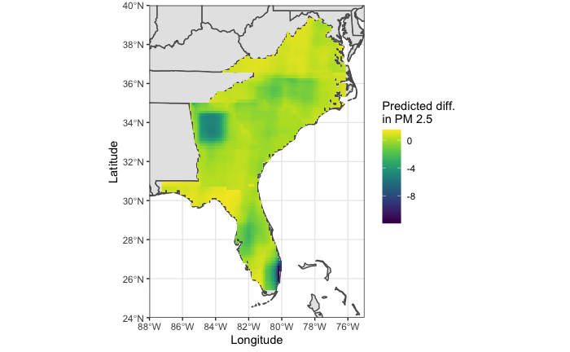

```r
(prediction.map <-
  ggplot(data = world)+
    geom_sf() +
    geom_sf(data = states)+
    # geom_point(data=pred.grid.final, aes(x=x, y=y, color=(mean.pred)), size=1.2, pch=15)+
    geom_raster(data=pred.grid.final, aes(x=x, y=y,fill=mean.sim.pred))+
    # scale_fill_gradient2(midpoint=0, mid="white", high="red", low="#0066ff", name="Predicted diff.\nin PM2.5")+
    scale_fill_gradientn(colours = viridis(10), name="Predicted diff.\nin PM 2.5")+
    coord_sf(xlim = c(-88, -75), ylim = c(24, 40), expand = FALSE)+
    xlab("Longitude")+
    ylab("Latitude")+
    # ggtitle("Bayesian Kriging Predictions of Difference in PM 2.5\nBetween 2020 and 2019")+
    theme(plot.title = element_text(hjust=0.5, face="bold")))
ggsave(prediction.map, file="/Volumes/\ macOS\ -\ Data/Users/tyler/Documents/Fall\ 2020/ST533/midterm1/figs/predicton_map4000.pdf", width=5, height=5)
```

### Make map of prediction SEs

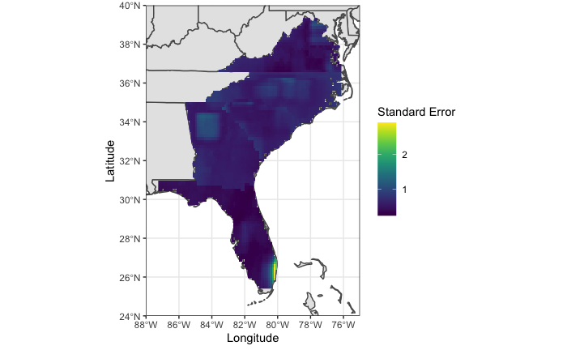

```r
(prediction.se.map <-
  ggplot(data = world)+
    geom_sf() +
    geom_sf(data = states)+
    # geom_point(data=pred.grid.final, aes(x=x, y=y, color=(se.sim.pred)), size=1.5, pch=22)+
    # scale_color_gradient(high="red", low="white", name="SE of predicted\ndiff. in PM2.5")+
    geom_raster(data=pred.grid.final, aes(x=x, y=y,fill=se.sim.pred))+
    scale_fill_gradientn(colours = viridis(10), name="Standard Error")+
    coord_sf(xlim = c(-88, -75), ylim = c(24, 40), expand = FALSE)+
    xlab("Longitude")+
    ylab("Latitude")+
    # ggtitle("Standard Errors of Bayesian Kriging Predictions\nof Diff. in PM2.5 Between 2020 and 2019")+
    theme(plot.title = element_text(hjust=0.5, face="bold")))
ggsave(prediction.se.map, file="/Volumes/\ macOS\ -\ Data/Users/tyler/Documents/Fall\ 2020/ST533/midterm1/figs/predictonSE_map4000.pdf", width=5, height=5)
```

### Make map of estimated values at sites

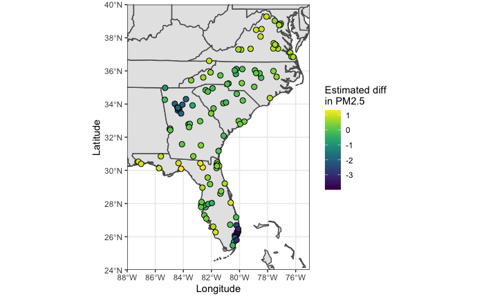

```r
(sites.map <-
  ggplot(data = world)+
    geom_sf() +
    geom_sf(data = states)+
     geom_point(data=by.site.final, aes(x=SITE_LONGITUDE, y=SITE_LATITUDE, fill=(mean.pred)), size=2.5, pch=21)+
    scale_fill_gradientn(colours=viridis(10), name="Estimated diff\nin PM2.5")+
    coord_sf(xlim = c(-88, -75), ylim = c(24, 40), expand = FALSE)+
    xlab("Longitude")+
    ylab("Latitude")+
    # ggtitle("Estimated Difference in Mean PM 2.5 from\nApril 1 to June 30 Between 2020 and 2019\nin FL, GA, NC, SC, and VA")+
    theme(plot.title = element_text(hjust=0.5, face="bold")))
ggsave(sites.map, file="/Volumes/\ macOS\ -\ Data/Users/tyler/Documents/Fall\ 2020/ST533/midterm1/figs/sites.map_4000.pdf", width=5, height=5)
```

### Make map of SE at sites

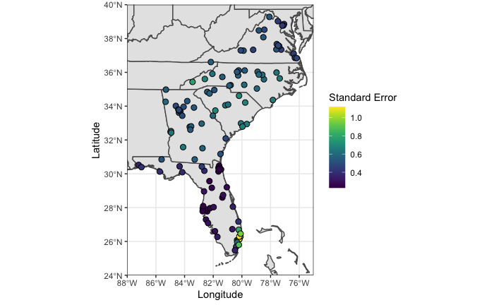

```r
(sites.se.map <-
  ggplot(data = world)+
    geom_sf() +
    geom_sf(data = states)+
     geom_point(data=by.site.final, aes(x=SITE_LONGITUDE, y=SITE_LATITUDE, fill=(se.sim.pred)), size=2.5, pch=21)+
    scale_fill_gradientn(colours=viridis(10), name="Standard Error")+
    coord_sf(xlim = c(-88, -75), ylim = c(24, 40), expand = FALSE)+
    xlab("Longitude")+
    ylab("Latitude")+
    # ggtitle("Standard Error of Estimated Difference\nof Mean PM 2.5 from\nApril 1 to June 30 Between 2020 and 2019\nin FL, GA, NC, SC, and VA")+
    theme(plot.title = element_text(hjust=0.5, face="bold")))
ggsave(sites.se.map, file="/Volumes/\ macOS\ -\ Data/Users/tyler/Documents/Fall\ 2020/ST533/midterm1/figs/sites.se.map_4000.pdf", width=5, height=5)
```

### Make a map of prediction sites that have a significant difference from 0

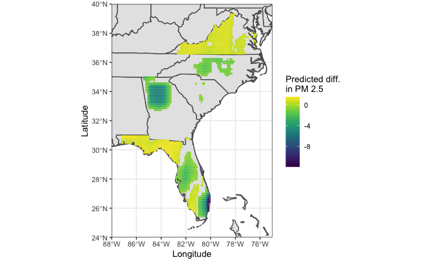

```r
#Get simulations for HDI
sims <- sp.fit.exp.nonug.aniso.bayes$predictive$simulations
sims.hdis <- as.data.frame(t(apply(sims, 1, FUN = function(x) hdi(x, credMass = 0.8))))
#Save to pred.grid.final
pred.grid.final$lower.hdi <- sims.hdis[(nrow(by.site.final)+1):nrow(sims.hdis),1]
pred.grid.final$upper.hdi <- sims.hdis[(nrow(by.site.final)+1):nrow(sims.hdis),2]
#Find ones that don't include 0
pred.grid.final.nonzero <- pred.grid.final[(pred.grid.final$lower.hdi < 0 & pred.grid.final$upper.hdi < 0) | (pred.grid.final$lower.hdi > 0 & pred.grid.final$upper.hdi > 0),]

#Make the map
(nonzero.prediction.map <-
  ggplot(data = world)+
    geom_sf() +
    geom_sf(data = states)+
    # geom_point(data=pred.grid.final, aes(x=x, y=y, color=(mean.pred)), size=1.2, pch=15)+
    geom_tile(data=pred.grid.final.nonzero, aes(x=x, y=y,fill=mean.sim.pred))+
    # scale_fill_gradient2(midpoint=0, mid="white", high="red", low="#0066ff", name="Predicted diff.\nin PM2.5")+
    scale_fill_gradientn(colours = viridis(10), name="Predicted diff.\nin PM 2.5")+
    coord_sf(xlim = c(-88, -75), ylim = c(24, 40), expand = FALSE)+
    xlab("Longitude")+
    ylab("Latitude")+
    # ggtitle("Bayesian Kriging Predictions of Difference in PM 2.5\nBetween 2020 and 2019\nWhere Difference is Non-Zero")+
    theme(plot.title = element_text(hjust=0.5, face="bold")))
ggsave(nonzero.prediction.map, file="/Volumes/\ macOS\ -\ Data/Users/tyler/Documents/Fall\ 2020/ST533/midterm1/figs/nonzero.predicton_map4000.pdf", width=5, height=5)
```

### Make a map of measurement sites that have a significant difference from 0

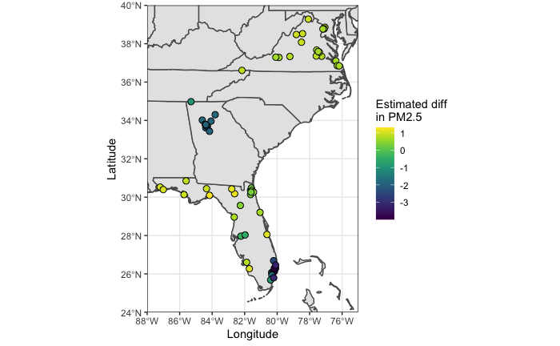

```r
#Get simulations for HDI
sims <- sp.fit.exp.nonug.aniso.bayes$predictive$simulations
sims.hdis <- as.data.frame(t(apply(sims, 1, FUN = function(x) hdi(x, credMass = 0.8))))
#Save to pred.grid.final
by.site.final$lower.hdi <- sims.hdis[1:nrow(by.site.final),1]
by.site.final$upper.hdi <- sims.hdis[1:nrow(by.site.final),2]
#Find ones that don't include 0
by.site.final.nonzero <- by.site.final[(by.site.final$lower.hdi < 0 & by.site.final$upper.hdi < 0) | (by.site.final$lower.hdi > 0 & by.site.final$upper.hdi > 0),]

#Make the map
(nonzero.site.map <-
  ggplot(data = world)+
    geom_sf() +
    geom_sf(data = states)+
    geom_point(data=by.site.final.nonzero, aes(x=SITE_LONGITUDE, y=SITE_LATITUDE, fill=(mean.pred)), size=2.5, pch=21)+
    scale_fill_gradientn(colours=viridis(10), name="Estimated diff\nin PM2.5")+
    coord_sf(xlim = c(-88, -75), ylim = c(24, 40), expand = FALSE)+
    xlab("Longitude")+
    ylab("Latitude")+
    # ggtitle("Estimated Difference in PM 2.5\nBetween 2020 and 2019\nWhere Difference is Non-Zero")+
    theme(plot.title = element_text(hjust=0.5, face="bold")))
ggsave(nonzero.site.map, file="/Volumes/\ macOS\ -\ Data/Users/tyler/Documents/Fall\ 2020/ST533/midterm1/figs/nonzero.site_map4000.pdf", width=5, height=5)
```

Model assumptions: Fitted vs residuals, qqnorm, variogram

```r
(fitted.residuals <- qplot(by.site.final$mean.sim.pred, by.site.final$mean.sim.pred - by.site.final$pm.diff)+xlab("Fitted values")+ylab("Residual values")+geom_hline(yintercept = 0))
ggsave(fitted.residuals, file="/Volumes/\ macOS\ -\ Data/Users/tyler/Documents/Fall\ 2020/ST533/midterm1/figs/fited.residuals.pdf", width=4, height=4)

pdf(file="/Volumes/\ macOS\ -\ Data/Users/tyler/Documents/Fall\ 2020/ST533/midterm1/figs/qqplot.pdf", width=4,height=4)
qqnorm(by.site.final$mean.sim.pred); qqline(by.site.final$mean.sim.pred)
dev.off()


plot_grid(plotlist=list(fitted.residuals, qqnorm(by.site.final$mean.sim.pred)), nrow=1, ncol=2, labels = c("a)", "b)"))

L <- 80
d_max <- 2
d <- seq(0,d_max,length=L)
vg <- variog(coords=subset(by.site.final, select=c(SITE_LATITUDE, SITE_LONGITUDE)), data=by.site.final$mean.sim.pred - by.site.final$pm.diff, uvec=d)

pdf(file="/Volumes/\ macOS\ -\ Data/Users/tyler/Documents/Fall\ 2020/ST533/midterm1/figs/final.vario.pdf", width=4, height=4)
final.vario <- plot(vg)
dev.off()
```

[output not shown]

Look at traceplots

```r
#Make iter column within each beta parameter
sp.fit.exp.nonug.aniso.bayes.samp.melt$iter <- rep(1:10000, 15)
traceplots <- qplot(iter, value, color=variable, geom="line", data=sp.fit.exp.nonug.aniso.bayes.samp.melt)+facet_wrap(~variable, ncol=5, scales = "free")+theme(legend.position = "none")+xlab("Iteration")+ylab("Posterior sample value")
ggsave(traceplots, file="/Volumes/\ macOS\ -\ Data/Users/tyler/Documents/Fall\ 2020/ST533/midterm1/figs/traceplots_4000.pdf", width=10, height=4)
ggsave(traceplots, file="/Volumes/\ macOS\ -\ Data/Users/tyler/Documents/Fall\ 2020/ST533/midterm1/figs/traceplots_4000.jpg", width=10, height=4)
```

Find distance between points on pred.grid

```r
pred.grid.final.sort <- pred.grid.final[order(pred.grid.final$x, pred.grid.final$y, decreasing = T),]
pred.grid.final.sort.coords <- subset(pred.grid.final.sort, select = c(x, y))
pred.grid.final.sort.dist <- as.matrix(dist(pred.grid.final.sort.coords, method="euclidean", diag = T, upper = T))
```

Save environment

```r
save.image(file="/Volumes/\ macOS\ -\ Data/Users/tyler/Documents/Fall\ 2020/ST533/midterm1/rdata/4000.pred.final.Rdata")
```

Make a map of votes for Trump

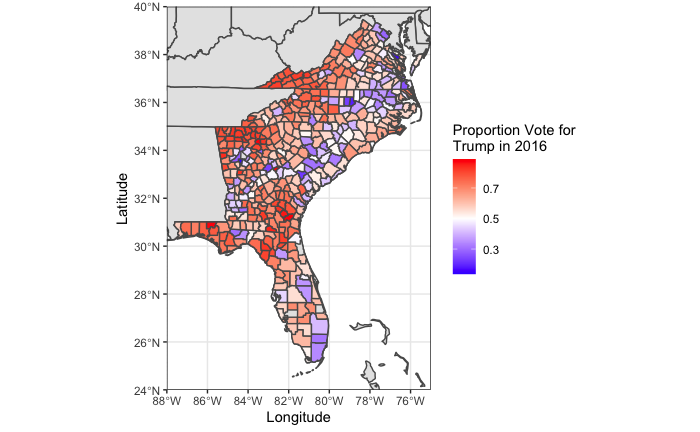

To Do: 3) Do Kriging from Bayesian model following his example 4) Find SE for each location and determine which ones have CIs that do not include 0 5) Make a map of Kriging predictions 6) Make a map of Kriging SEs 7) Make a map of sites that have significant differences in PM 2.5